# Atividade 4 - Checkpoint 2

Dandara Sousa

27 de julho de 2017

## O conjunto de dados

Temos, aqui, uma amostra dos commits dados no [GitHub](http://github.com/) no período 2016-2017. É possível observar a quantidade de pessoas que editaram arquivos de uma determinada extensão durante os dois anos.Os dados brutos contém a contagem de quantas pessoas editaram arquivos com cada extensão de arquivo em cada dia de 2016 e 2017 no github. Não temos dados de todos os repositórios nem de todos os usuários, portanto estamos trabalhando com uma amostra.

Anteriormente tínhamos duas questões:

**1. Para cada uma das linguagens de programação, há uma diferença significativa na sua popularidade durante a semana e durante o fim de semana? Essa diferença é grande?**

**2. Existe uma diferença significativa entre as duas linguagens na sua variação de popularidade nos finais de semana?**

Ambas as questões foram respondidas tomando base as duas linguagens mais populares: Markdown e Javascript.

A partir do trabalho na amostra, é interessante mexer de formas mais ampla. Primeiramente, dado que temos 2016 como um ano com dados em todos os meses, é curioso de se saber quando os programadores foram mais produtivos e também ver se o padrão do mês em 2016 está se repetindo em 2017. Em segundo lugar, trabalhando nos finais de semanas e sabendo que Markdown é a linguagem mais popular pode-se observar a popularidade de forma isolada nos finais de semana. Ou seja, analisar a popularidade no sábado e no domingo. Será que os programadores deixam para programar nos últimos momentos do final de semana ou mantém o clima da sexta e programam mais no sábado?

Para começo de conversa, organizamos nossos dados:

```r
conjunto = read.csv("github-users-committing-filetypes.csv")

dados <- conjunto %>%
  unite("data", the_year, the_month, month_day, sep = "-") %>%
  mutate(data = as.Date(strptime(data, "%Y-%m-%d"))) %>%
  mutate(iswknd = is.weekend(data)) %>%
  mutate(dia_semana = weekdays(data))
```

E, agora, partimos para responder nossas questões:

*1. Qual mês teve mais contribuição em 2016, de acordo com a amostra? E em 2017 até agora?*

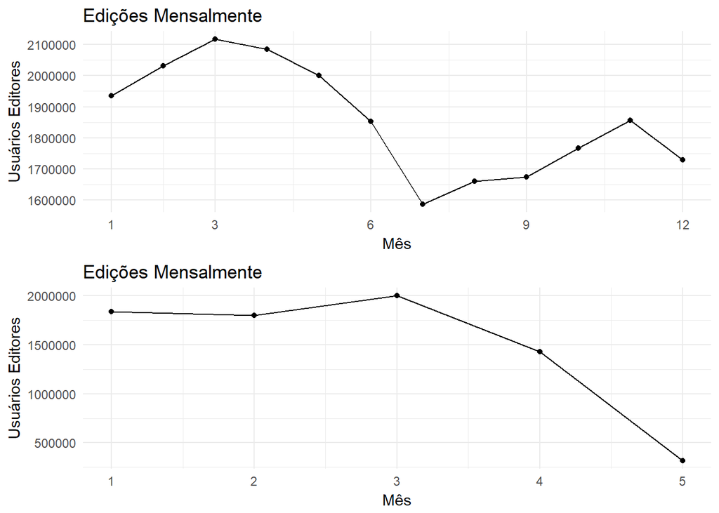

```r
dados.2016 = conjunto %>% filter(the_year == "2016")

dados.2016 = dados.2016 %>%
  group_by(the_month) %>%
  mutate(month_users = sum(users))

p1 = dados.2016 %>%
  ggplot(aes(x= the_month, y = month_users)) +
  geom_line() +
  geom_point() +
  scale_x_continuous(breaks=c(1,3,6,9,12)) +
  labs(title = "Edições Mensalmente", x = "Mês" , y= "Usuários Editores", colour = "Ano") +
  theme_minimal()

dados.2017 = conjunto %>% filter(the_year == "2017")

dados.2017 = dados.2017 %>%
  group_by(the_month) %>%
  mutate(month_users = sum(users))

p2 = dados.2017 %>%
  ggplot(aes(x= the_month, y = month_users)) +
  geom_line() +
  geom_point() +
  labs(title = "Edições Mensalmente", x = "Mês" , y= "Usuários Editores", colour = "Ano") +
  theme_minimal()

grid.arrange(p1,p2)
```

A partir dos gráficos observamos que o pico de produção em 2016 é em Março e, em 2017 até então, esse também é. E, de forma geral, o padrão de 2016 está sendo seguido em 2017.

2. A linguagem mais popular, é mais popular no sábado ou no domingo?

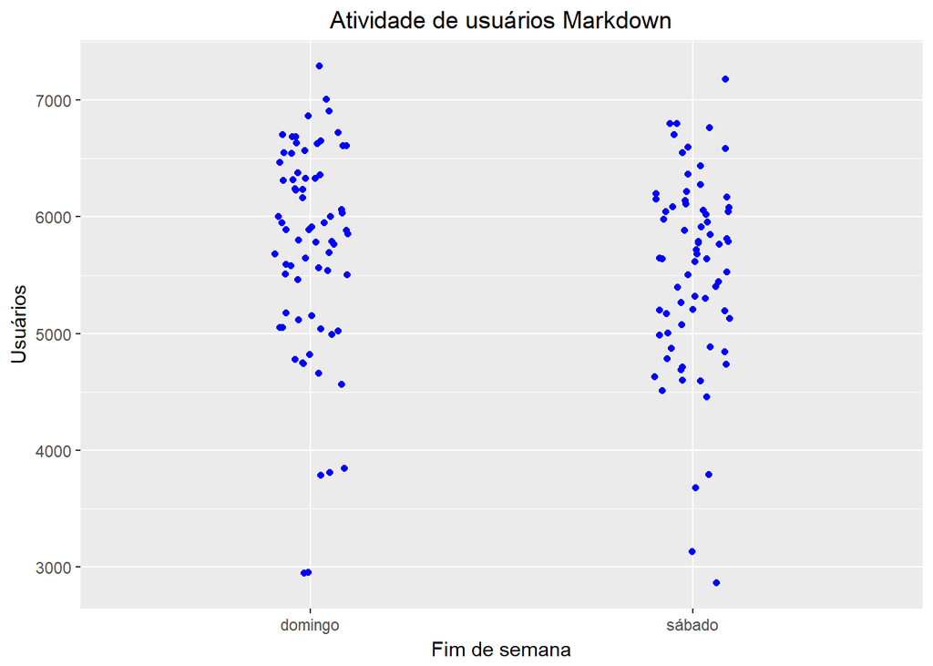

```r
md = dados %>% filter(file_extension == "md"& iswknd == TRUE)
md.sabado = md %>% filter(dia_semana == "sábado")
md.domingo = md %>% filter(dia_semana == "domingo")

md %>%
  ggplot(aes(x = dia_semana, y = users)) +
  geom_jitter(width = .1, color = "blue") +
  labs(title = "Atividade de usuários Markdown", x = "Fim de semana", y = "Usuários") +
  theme(plot.title = element_text(hjust = 0.5))
```

Olhando rapidamente não conseguimos ver muita diferença para afirmar de certeza qual é o dia do final de semana preferido pelo os programadores de md.